# Auto-evaluate weight-lifter’s performance

Paul Denny

18/10/2014

### Summary

This project evaluates the data from six weight-lifting participants who had accelerometers fitted to their belt, forearm, arm, and dumbell. They were asked to perform barbell lifts correctly and incorrectly in five different ways. The project should fit a model to this data that can best classify these five categories from the 159 predictors made available in the dataset.

More information is available from the website: groupware.les.inf.puc-rio.br/har

**A Random Forest model was fitted and provided an accuracy of 99.44% when cross-validated on the test data.**

### Data Analysis

#### Load libraries and the data and set the seed for repeatability

```r
# load required libraries,
require(caret, quietly=TRUE)
require(randomForest, quietly=TRUE)

# set seed for repeatability
set.seed(1961)

# download data from internet if necessary
if (!file.exists("pml-data.csv"))
  download.file("http://d396qusza40orc.cloudfront.net/predmachlearn/pml-training.csv", "pml-data.csv")
if (!file.exists("pml-quest.csv"))
  download.file("http://d396qusza40orc.cloudfront.net/predmachlearn/pml-testing.csv", "pml-quest.csv")

#load data, assigning NA to missing data
pmlData <- read.csv("pml-data.csv", na.strings=c("","NA","#DIV/0!"))
pmlQuest <- read.csv("pml-quest.csv", na.strings=c("","NA","#DIV/0!"))

# size of the data set is [19623, 160]
dim(pmlData)
```

```
## [1] 19622   160
```

#### Cleanse the data of unnecessary columns due to NA’s or other superfluous information

```r
# remove variable/predictor columns where most data are NA, ie more than 97.5%
NA.cols <- as.data.frame(sapply(pmlData, function(x) length(x[is.na(x)])/length(x)))
NA.cols <- row.names(NA.cols[NA.cols > 0.975,,drop=FALSE])
pmlData <- pmlData[, -which(names(pmlData) %in% NA.cols)]

# remove superfluous index, sequence info date/time and subject identity
pmlData <- pmlData[, -which(names(pmlData) %in% c('X', 'user_name', 'raw_timestamp_part_1',
                                                  'raw_timestamp_part_2', 'cvtd_timestamp',
                                                  'new_window', 'num_window'))]

dim(pmlData)
```

```
## [1] 19622    53
```

#### Partition the data into training (80%) and testing (20%) sets

```r
# partition data into a training (80%) and testing set (20%)
trainIndex = createDataPartition(pmlData$classe, p = 4/5, list=FALSE)
training = pmlData[trainIndex,]; testing = pmlData[-trainIndex,]
```

#### Use Random Forest (Decision Tree Ensemble Method Classifier)

A Random Forest approach was chosen as it is one of the top performing algorithms for accuracy in classification prediction with some resilience to over-fitting and in-built cross-validation and oob error metrics (equivalent to out of sample error). Examining the variable importance for further understanding of the data or tuning of the data model is also extremely useful.

```r
# Fit Random Forest Model
# If the model hasn't already been run - run it, recording how long it takes and save it.
if (!file.exists("modelFit.RData")) {
    system.time(modelFit <- train(training$classe ~ ., method="rf", importance=TRUE, data=training))
    save(modelFit, file="modelFit.RData")
} else {
    load(file="modelFit.RData")
}
# Run-time 5 hours 28 minutes on HP Workstation XW4400 with 4GB and no GX CORES, CPU:
# http://ark.intel.com/products/27249/Intel-Core2-Duo-Processor-E6400-2M-Cache-2_13-GHz-1066-MHz-FSB
```

#### Random Forest Final Model Results

`modelFit <- train(training$classe ~ ., method="rf", importance=TRUE, data=training`

```r
#  Model Results:
modelFit
```

```
## Random Forest
##
## 15699 samples
##    52 predictors
##     5 classes: 'A', 'B', 'C', 'D', 'E'
##
## No pre-processing
## Resampling: Bootstrapped (25 reps)
##
## Summary of sample sizes: 15699, 15699, 15699, 15699, 15699, 15699, ...
##
## Resampling results across tuning parameters:
##
##   mtry  Accuracy  Kappa  Accuracy SD  Kappa SD
##    2    1         1      0.001        0.002
##   27    1         1      0.002        0.002
##   52    1         1      0.004        0.005
##
## Accuracy was used to select the optimal model using  the largest value.
## The final value used for the model was mtry = 27.
```

```r
modelFit$finalModel
```

```
##
## Call:
##  randomForest(x = x, y = y, mtry = param$mtry, importance = TRUE)
##                Type of random forest: classification
##                      Number of trees: 500
## No. of variables tried at each split: 27
##
##         OOB estimate of  error rate: 0.57%
## Confusion matrix:
##      A    B    C    D    E class.error
## A 4456    7    1    0    0    0.001792
## B   19 3014    5    0    0    0.007900
## C    0   11 2719    8    0    0.006939
## D    0    1   25 2544    3    0.011271
## E    0    0    3    7 2876    0.003465
```

The Random Forest OOB, out of bag error, is shown above to be *0.57%* and gives us a reasonably unbiased approximation to the *Out of Sample Error* due to the ensemble method used. This model looks promissing.

#### Variable Importance for this Random Forest Model

There are six dominant predictors of importance in this model, they are:

`roll_belt pitch_forearm yaw_belt magnet_dumbell_y magnet_dumbell_z pitch_belt`

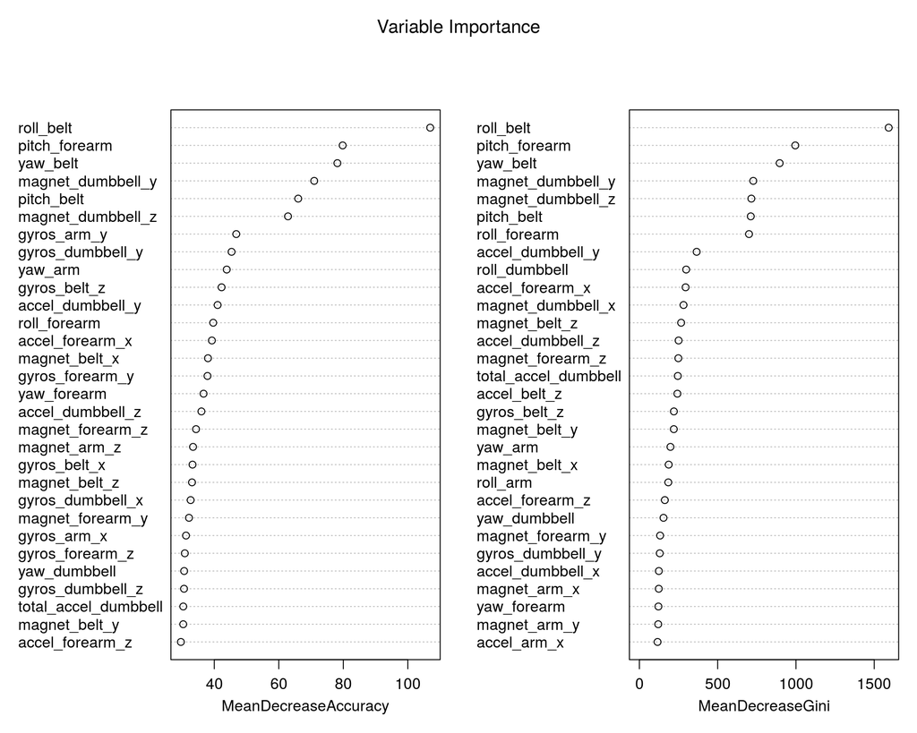

#### Cross Validate with the Test Data

Random Forest incorporates cross validation and out of sample error estimates via OOB, but further validation on a separate test set is good practice, at least to highlight possible over-fitting.

The confusion matrix for our model predicting against the test data set shows an accuracy of 99.44%, almost exactly as expected given the OOB of 0.57% above, not only does this show our model to be accurate when cross validated on the test data, with an **Out of Sample Error** of **0.56%**, it shows no tendency to over-fitting.

```r
confusionMatrix(testing$classe, predict(modelFit,testing))
```

```
## Confusion Matrix and Statistics
##
##           Reference
## Prediction    A    B    C    D    E
##          A 1115    0    0    0    1
##          B    2  757    0    0    0
##          C    0    3  678    3    0
##          D    0    0    9  634    0
##          E    0    1    3    0  717
##
## Overall Statistics
##
##                Accuracy : 0.994
##                  95% CI : (0.992, 0.996)
##     No Information Rate : 0.285
##     P-Value [Acc > NIR] : <2e-16
##
##                   Kappa : 0.993
##  Mcnemar's Test P-Value : NA
##
## Statistics by Class:
##
##                      Class: A Class: B Class: C Class: D Class: E
## Sensitivity             0.998    0.995    0.983    0.995    0.999
## Specificity             1.000    0.999    0.998    0.997    0.999
## Pos Pred Value          0.999    0.997    0.991    0.986    0.994
## Neg Pred Value          0.999    0.999    0.996    0.999    1.000
## Prevalence              0.285    0.194    0.176    0.162    0.183
## Detection Rate          0.284    0.193    0.173    0.162    0.183
## Detection Prevalence    0.284    0.193    0.174    0.164    0.184
## Balanced Accuracy       0.999    0.997    0.990    0.996    0.999
```

#### Conclusion

As an aside the researcher did examine the predictive power of the dumbbell sensors alone and was able to achieve 90% accuracy with the above model, and if this was research towards a real-world product, would focus on the dumbbell sensors alone, smartbells are coming!

#### Appendix

**Answer 20 predictions to submit to coursera as individual files**

```r
pmlAnswers <- predict(modelFit,pmlQuest)

pmlAnswers
```

```
##  [1] B A B A A E D B A A B C B A E E A B B B
## Levels: A B C D E
```

```r
for(i in 1:length(pmlAnswers)) {
    filename = paste("pmlAnswers/problem_id_", i, ".txt", sep="")
    write.table(pmlAnswers[i],file=filename,quote=FALSE,row.names=FALSE,col.names=FALSE)
}
```

**Link to the R Markdown for this page on the GitHub Repository Website:**

[R Markdown](https://github.com/bayofislands/PML/raw/master/index.Rmd)

**Link to HTML for this page on the GitHub Pages Website:**

[HTML](http://bayofislands.github.io/PML/)